# MSCA 31008 HW3-Part2

Ruoxin Shi

2022/2/3

## Principle Component

### Import, Standardized and Split data

**Data description:**  
CRIM - per capita crime rate by town  
ZN - proportion of residential land zoned for lots over 25,000 sq.ft.  
INDUS - proportion of non-retail business acres per town.  
CHAS - Charles River dummy variable (1 if tract bounds river; 0 otherwise)  
NOX - nitric oxides concentration (parts per 10 million)  
RM - average number of rooms per dwelling AGE - proportion of owner-occupied units built prior to 1940  
DIS - weighted distances to five Boston employment centres  
RAD - index of accessibility to radial highways  
TAX - full-value property-tax rate per $10,000  
PTRATIO - pupil-teacher ratio by town  
B - 1000(Bk - 0.63)^2 where Bk is the proportion of blacks by town  
LSTAT - % lower status of the population  
MEDV - Median value of owner-occupied homes in $1000’s

```r
data("Boston")

# keep only numeric data
# chas is a categorical
df <- subset(Boston, select = -c(chas))

# standardize and split the data
#df <- scale(df)

set.seed(1123)
sample_size <- round(0.7 * nrow(df))
train_ind <- sample(seq_len(nrow(df)), size = sample_size, replace=FALSE)
train <- df[train_ind, ]
test <- df[-train_ind, ]

train_mean <- colMeans(train)
train_std <- apply(train, 2, sd)
train <- scale(train, center = train_mean, scale = train_std)
test <- scale(test, center = train_mean, scale = train_std)
```

### Perform PCA and check result

```r
m1 <- prcomp(train)
VAF <- cumsum(m1$sdev^2/sum(m1$sdev^2))
```

#### Plot VAF Scree Plot

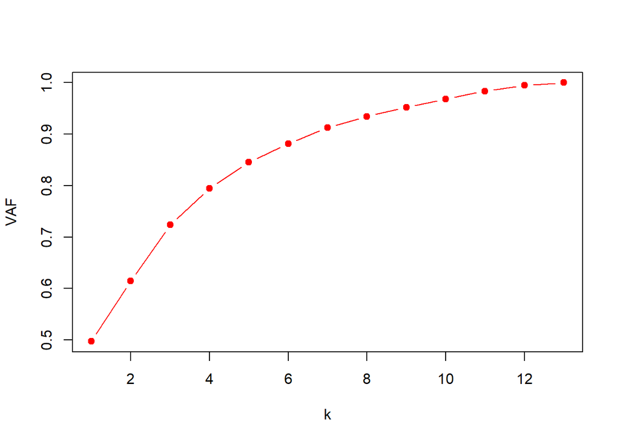

```r
x <- 1:13
plot(x, VAF, type = "b", pch = 19, col = "red", xlab = "k", ylab = "VAF")
```

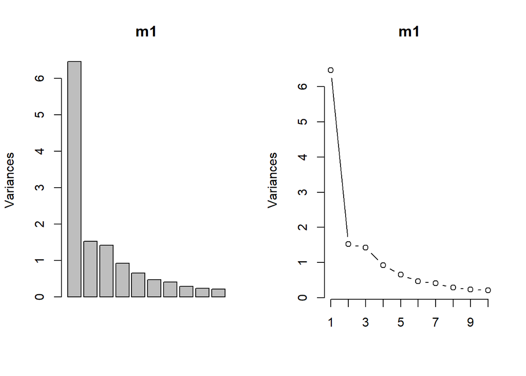

```r
layout(matrix(1:2, ncol=2))
screeplot(m1)
screeplot(m1, type="lines")
```

```r
summary(m1)
```

```
## Importance of components:
##                           PC1    PC2    PC3     PC4     PC5     PC6     PC7     PC8
## Standard deviation     2.5426 1.2342 1.1924 0.96080 0.80999 0.68185 0.64011 0.53321
## Proportion of Variance 0.4973 0.1172 0.1094 0.07101 0.05047 0.03576 0.03152 0.02187
## Cumulative Proportion  0.4973 0.6145 0.7238 0.79484 0.84530 0.88107 0.91259 0.93446
##                            PC9    PC10    PC11    PC12   PC13
## Standard deviation     0.48296 0.45718 0.44515 0.38127 0.2574
## Proportion of Variance 0.01794 0.01608 0.01524 0.01118 0.0051
## Cumulative Proportion  0.95240 0.96848 0.98372 0.99490 1.0000
```

From the summary and scree plot above we know that first 7 priciple components have a cumulative proportion of 91.259%, which is good enough. So I would choose the first 7 principle components.

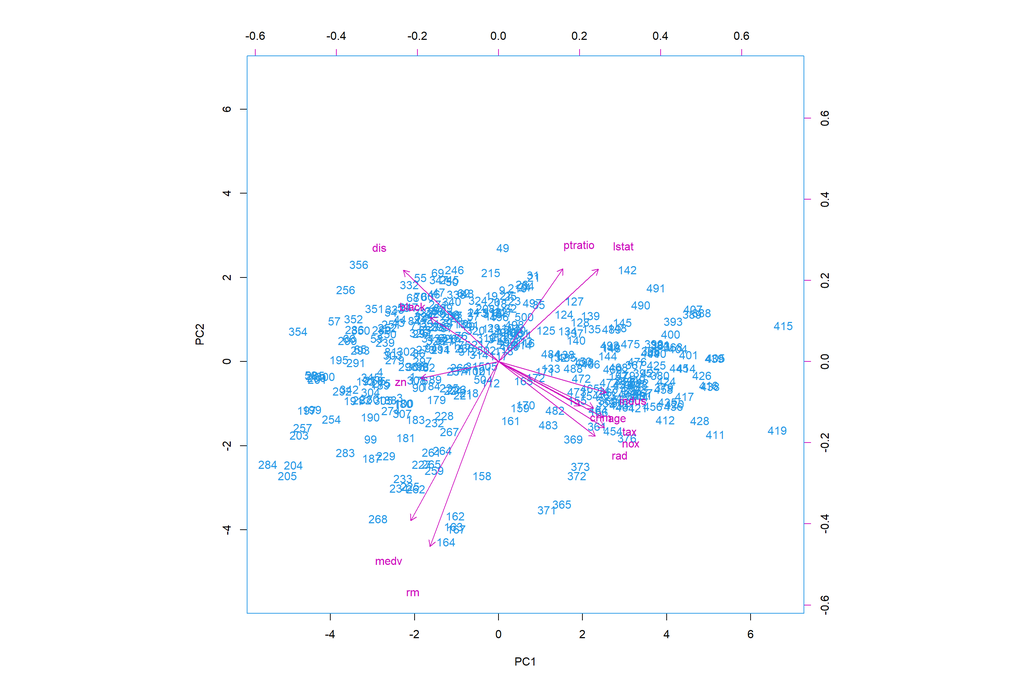

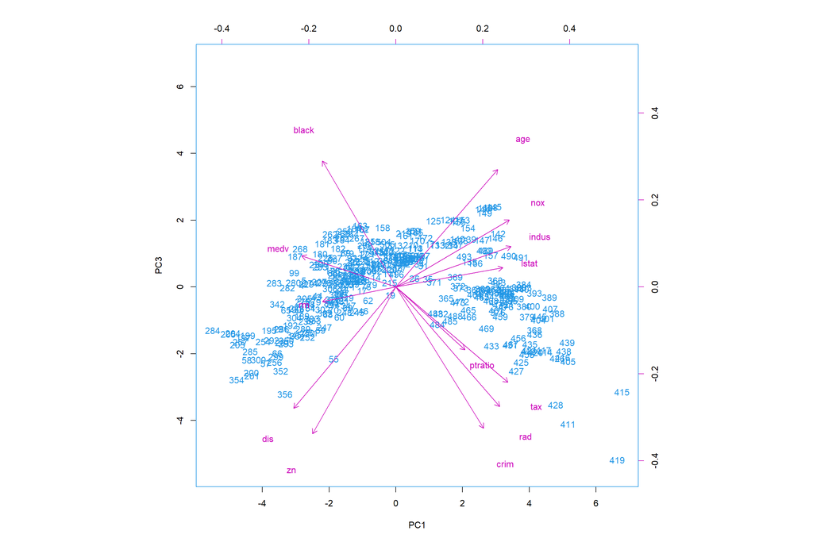

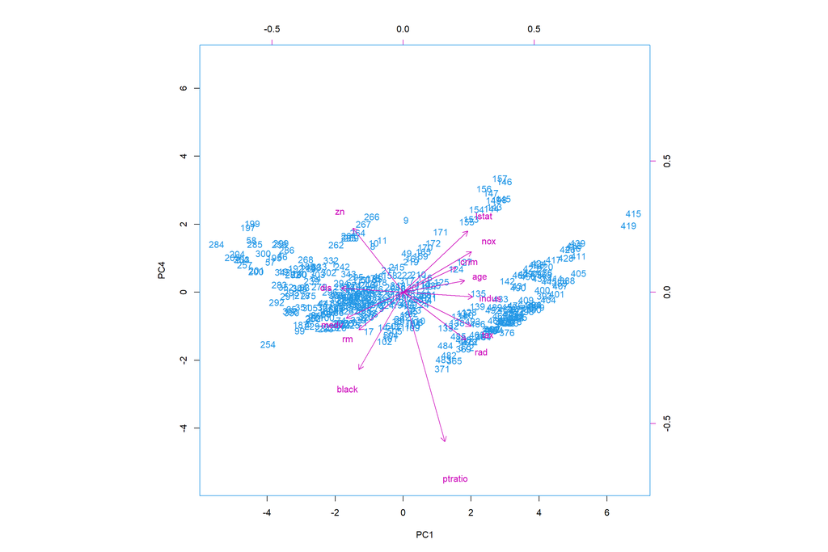

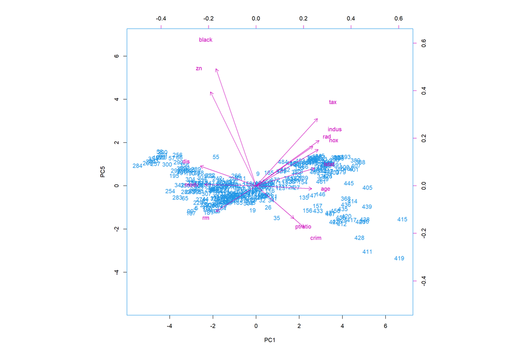

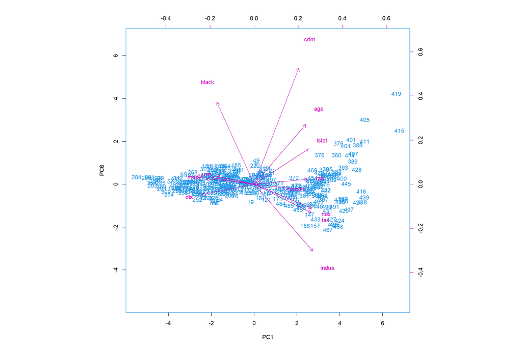

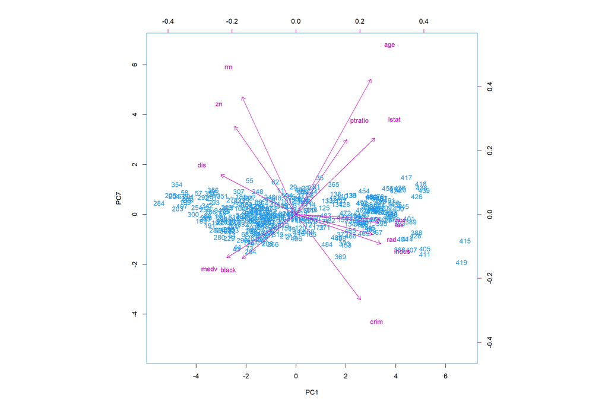

```r
#par(mfrow=c(6, 1))
for (i in 2:7) {
  biplot(m1$x[,c(1,i)],m1$rotation[,c(1,i)], cex=1,col=c(4,6))
}
```